##### **Fig. C.16:** Conditional distribution(s) of current and prior scale scores: Mathematics.

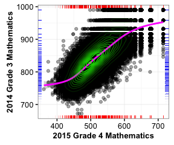

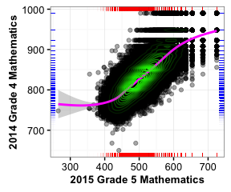

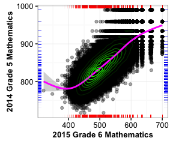

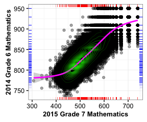

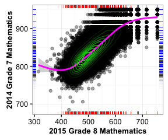

### 2.2.2 End-of-Course Test Subjects

The conditional density plots for the EOC test subjects are displayed below. The most recent prior is used in each plot to provide insight on each academic peer (norm) group that were analyzed separately. Note the bottom-left plot in Figure C.17 below for Grade 9 Literature course repeaters, particularly the point in the upper-right hand corner of the plot. This is a potential indicator for a ceiling effect issue. Several other individual plots in other subjects also display a similar indicators, including other course repeaters and progressions with skipped years.

##### **Fig. C.17:** Conditional distribution(s) of current and prior scale scores: 9<sup>th</sup> Grade Lit.

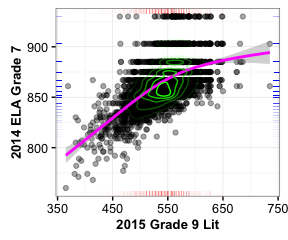

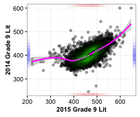

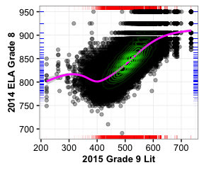

##### **Fig. C.18:** Conditional distribution(s) of current and prior scale scores: American Lit.

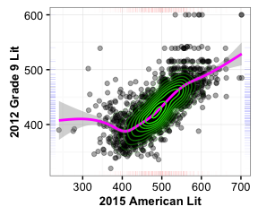

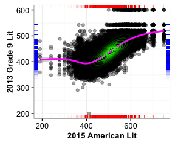

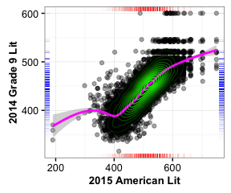

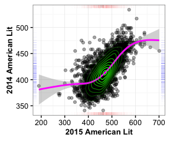

##### **Fig. C.19:** Conditional distribution(s) of current and prior scale scores: US History.

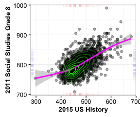

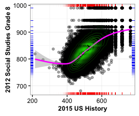

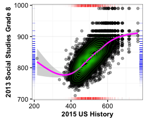

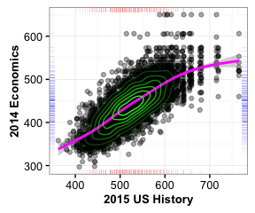

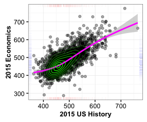

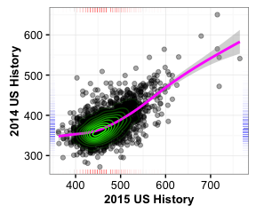

##### **Fig. C.20:** Conditional distribution(s) of current and prior scale scores: Economics.

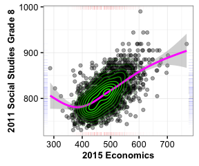

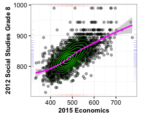

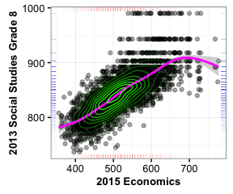

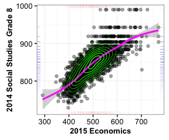

##### **Fig. C.21:** Conditional distribution(s) of current and prior scale scores: Economics *Continued*.

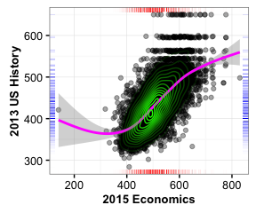

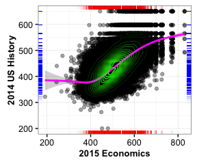

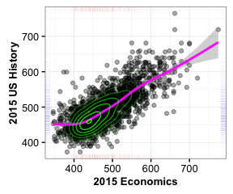

##### **Fig. C.22:** Conditional distribution(s) of current and prior scale scores: Biology.

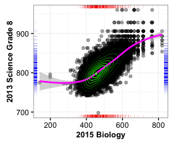

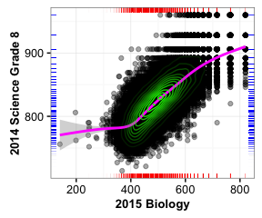

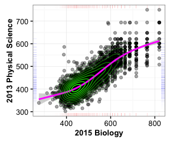

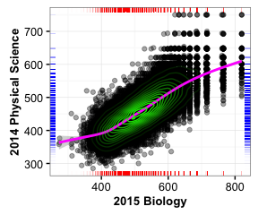

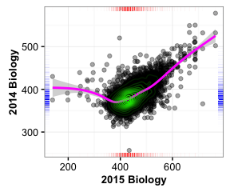

##### **Fig. C.23:** Conditional distribution(s) of current and prior scale scores: Physical Science.

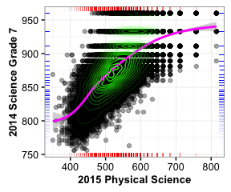

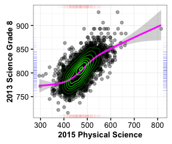

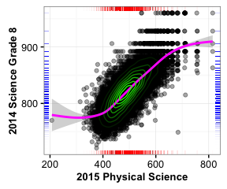

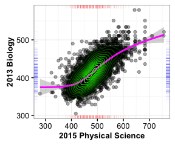

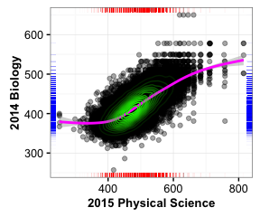

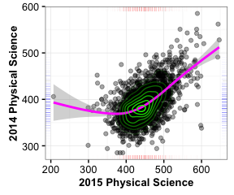

##### **Fig. C.24:** Conditional distribution(s) of current and prior scale scores: Coordinate Algebra.

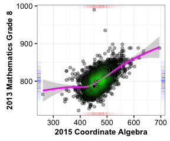

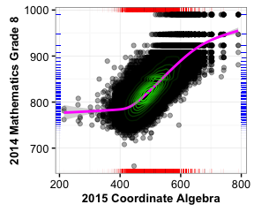

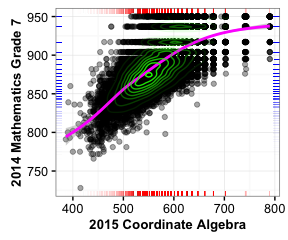

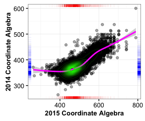

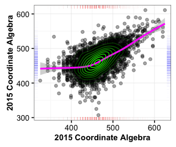

##### **Fig. C.25:** Conditional distribution(s) of current and prior scale scores: Analytic Geometry.

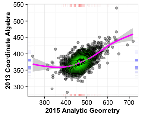

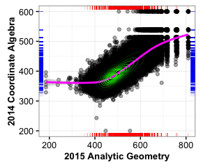

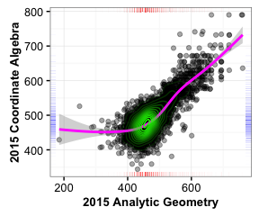

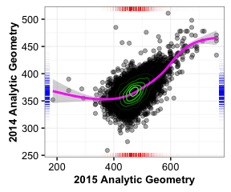

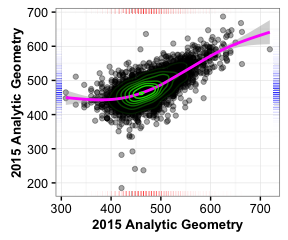

# 3 SGP Ranges for the Highest and Lowest Achieving Students

In order to isolate the impact of assessment ceilings/floors on student growth percentile (SGP) calculations, the following section provides box plots of the distribution of SGPs for the highest and lowest achieving students. We are specifically interested in the growth percentiles for students scoring at the highest/lowest obtainable scale score (HOSS/LOSS - i.e. the artificial test ceiling/floor) on the current year test. However, in order to assure that an adequate number of students are included, the first set of plots in each subsection uses, at a *minimum*, the highest/lowest 50 scores. Note that this roughly corresponds to the number of students used in the SGP model goodness of fit plots, and this is why these plots are provided as a starting point for this part of the investigation. All students with a score in these students’ range of scores are included. Consequently, the number of students in each box plot may be greater than 50 (the exact number is shown at the margins in red text).

The second set of box plots in the following subsections isolate *only* those students scoring the HOSS/LOSS. These plots may then incorporate a widely varying number of students depending on the prevalence of a ceiling/floor in the current year. Note that because Georgia uses the SIMEX measurement error corrected SGP as the official SGP, that is the version used here.

The box plots provide several descriptive statistics. The dark line within the box marks the *median* SGP, while the ends (“hinges”) of the boxes correspond to the first and third quartiles (the 25<sup>th</sup> and 75<sup>th</sup> percentiles). The upper whisker extends from the hinge to the highest value that is within 1.5 $×$ IQR of the hinge, where IQR is the inter-quartile range, or distance between the first and third quartiles. The lower whisker extends from the hinge to the lowest value within 1.5 $×$ IQR of the hinge. Data beyond the end of the whiskers are outliers and plotted as points. Evidence of a *lack* of either a ceiling or floor effect would be to have all high achieving students with SGPs near 99 and all low achieving students with SGPs near 1. That is, the desired visual evidence is a solid line at SGP = 99/1.

## 3.1 EOG Content Areas

##### **Fig. C.26:** EOG SGP distributions for highest and lowest 50+ scale scores by content area and grade level.

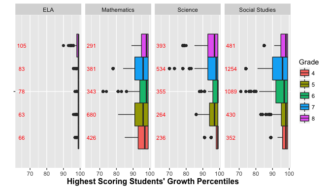

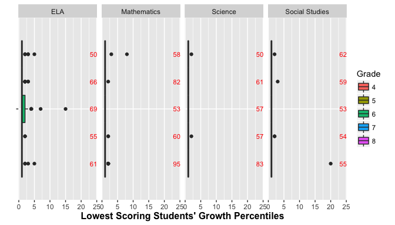

##### **Fig. C.27:** EOG SGP distributions for the HOSS and LOSS scores by content area and grade level.

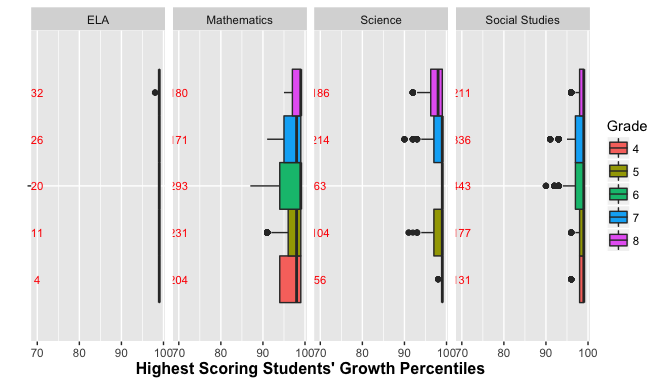

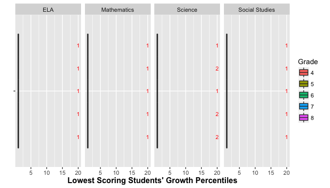

## 3.2 EOC Subjects

The end-of-course subject results are shown here *only for students scoring exactly the LOSS and HOSS*. There are several subjects for which potential ceiling effects are evident. These subjects are disaggregated further in order to more appropriately address these concerns.

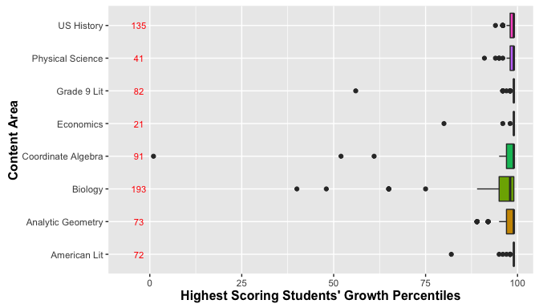

The end-of-course box plots can be disaggregated further by the most recent prior (i.e. their constituent norm groups). The following box plots disaggregate each EOC subject by norm groups. A pattern emerges in these plots that suggests that the problematic course progressions are those for course repeaters and those that included skipped years.

In the Grade 9 Literature plots below we see the potentially problematic single case from the course repeater analysis (highlighted earlier in the bottom-left panel of Figure C.17). This student has scored perfectly on both tests (which begs the question as to why this student was re-taking the test to begin with), and, given her relation to the rest of this cohort, the SGP model has estimated this to be a relatively common occurence with an SGP of 56. This may be a fair assessment of the conditional probability of staying perfect, but is hard to justify as a description of this student’s growth.

##### **Fig. C.29:** EOC SGP distributions for the HOSS and LOSS scores by norm group: 9<sup>th</sup> Grade Literature.

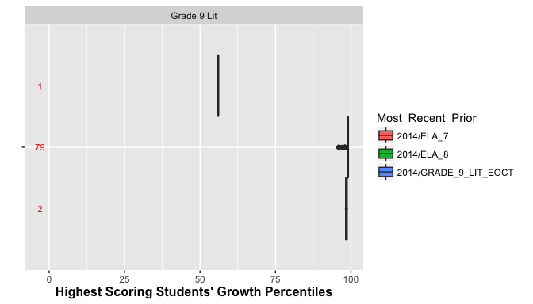

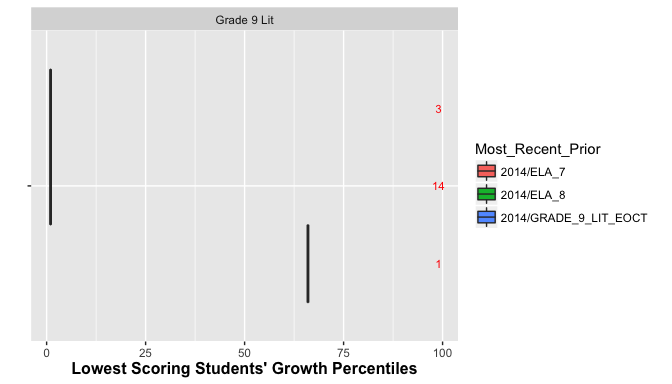

##### **Fig. C.30:** EOC SGP distributions for the HOSS and LOSS scores by norm group: American Lit.

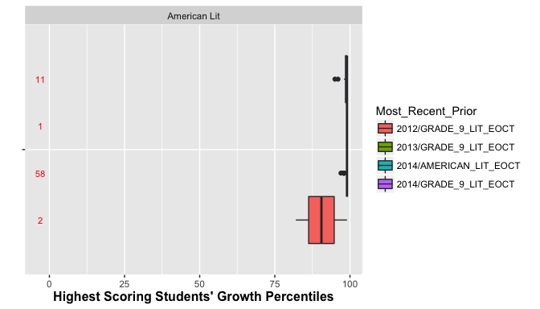

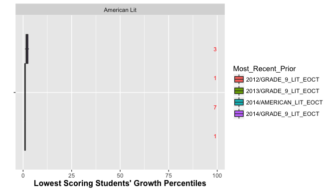

##### **Fig. C.31:** EOC SGP distributions for the HOSS and LOSS scores by norm group: US History.

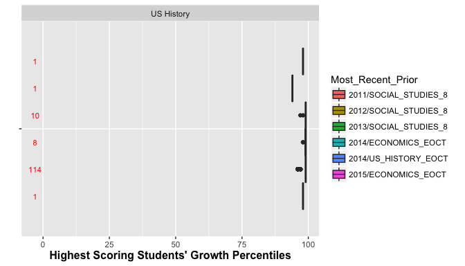

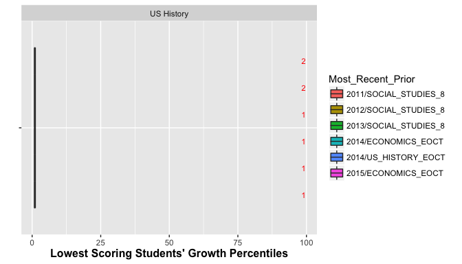

##### **Fig. C.32:** EOC SGP distributions for the HOSS and LOSS scores by norm group: Economics.

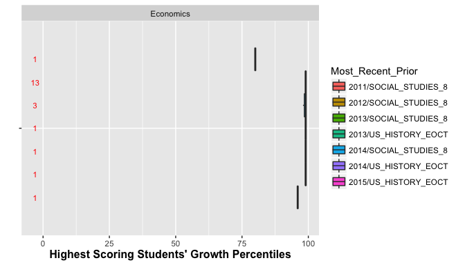

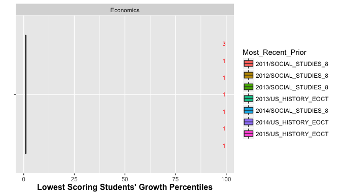

The plots for Biology are notable, particularly for the course repeater progression. This progression can also be seen in last plot of Figure C.22 above. Here we have isolated three students who scored the Milestones HOSS, 765. These student’s prior scale scores are all relatively high compared to the other repeaters, yet there is a range in their three prior scores from 502 to 578. This translates to a range in SGPs from 97 to 40, and may be considered a minor ceiling effect for the highest attaining student.

##### **Fig. C.33:** EOC SGP distributions for the HOSS and LOSS scores by norm group: Biology.

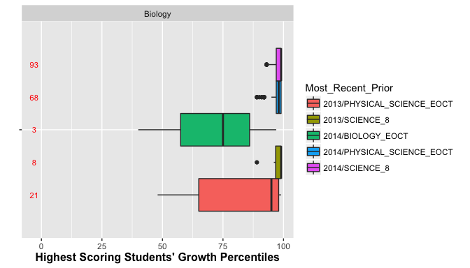

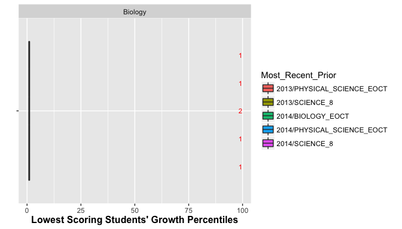